# Airbnb Data Analytics

Answering several data analysis questions using our RSQLite database setup in the previous post

Nils Dosaj Mikkelsen, Jose Lama https://example.com/norajones  
2022-03-28

## Introduction

In this post, we demonstrate how to answer a number of questions related to room listing type and host info using our newly created RSQLite database.

## Questions

We answer the following 11 questions:

### Room Listing

1. What is the most common room type available?
2. What is the top and bottom 10 property type based on average price?
3. What is the top and bottom 10 property type based on review score?
4. What is the most common amenities provided?
5. Is there any correlation between room price and the review score?
6. Room listing geographical distribution

### Host

7. Who are the top 10 host based on revenue?
8. Is there any difference in review score between superhost and normal host?
9. Is there any difference in response rate between superhost and normal host?
10. What is the most commonly verified host information?
11. How has the number of hosts joining airbnb increased/decreased overtime?

## Libraries, Database Connection and Functions

### Libraries

First, we must load the necessary libraries required for our data analysis and connect to our database.

```r
# Libraries
library(DBI)
library(RSQLite)
library(tidyr)
library(tibble)
library(dbplyr)
library(dplyr, warn.conflicts = FALSE)
library(leaflet)
library(lubridate)
library(ggplot2)
library(gridExtra)
library(tidyquant)
library(zoo)
```

### Database Connection

Next, we connect to our database that we set up in the previous post

```r
con <- dbConnect(RSQLite::SQLite(), "airdb.SQLite")
```

### The `build_airbnb_database()` Function

```r
build_airbnb_database <- function(con, listing_data, remove_old_database = FALSE){

    #################### Remove Existing database
    if(remove_old_database == TRUE){
        remove_live_database(con)
    }

    #################### Deal with NA values
    listing_data <-
        listing_data %>%

        # Convert dates to characters for NA values
        mutate(last_scraped = as.character(last_scraped),
               host_since = as.character(host_since),
               calendar_last_scraped = as.character(calendar_last_scraped),
               first_review = as.character(first_review),
               last_review = as.character(last_review),
               ) %>%

        # Homogenize NA values
        #*# Taken from: https://rpubs.com/Argaadya/create_table_sql
        mutate_all(function(x) ifelse(x == "" | x == "None" | x == "N/A", NA, x)) %>%  #*#
        # mutate_all(function(x) ifelse(is.na(x), "NULL", x)) %>%

        # Convert character strings back to date type
        mutate(last_scraped = as.Date(last_scraped),
               host_since = as.Date(host_since),
               calendar_last_scraped = as.Date(calendar_last_scraped),
               first_review = as.Date(first_review),
               last_review = as.Date(last_review))


    #################### Extract host data
    host_data <- listing_data %>%
        select(host_id:host_identity_verified,
               calculated_host_listings_count:calculated_host_listings_count_shared_rooms)


    #################### Remove duplicate values
    host_data <- host_data %>% distinct()


    #################### Convert dates
    # Note that this will need to converted back to type = date for analysis
    host_data  <- host_data %>% mutate(host_since = as.character(host_since))


    #################### Clean host verification column
    host_data <-
        host_data %>%
        mutate(host_verifications = str_remove_all(host_verifications, "[\\'\\[\\]]"))


    #################### Create table for host info
    query <- "CREATE TABLE host_info(
        host_id INT,
        host_url VARCHAR(50),
        host_name VARCHAR(100),
        host_since VARCHAR(50),
        host_location VARCHAR(500),
        host_about VARCHAR(10000),
        host_response_time VARCHAR(50),
        host_response_rate VARCHAR(50),
        host_acceptance_rate VARCHAR(50),
        host_is_superhost BOOLEAN,
        host_thumbnail_url VARCHAR(500),
        host_picture_url VARCHAR(500),
        host_neighbourhood VARCHAR(50),
        host_listings_count INT,
        host_total_listings_count INT,
        host_verifications VARCHAR(500),
        host_has_profile_pic BOOLEAN,
        host_identity_verified BOOLEAN,
        calculated_host_listings_count INT,
        calculated_host_listings_count_entire_homes INT,
        calculated_host_listings_count_private_rooms INT,
        calculated_host_listings_count_shared_rooms INT,
        PRIMARY KEY(host_id)
        )"


    #################### Load host_info table
    dbSendQuery(con, query)


    #################### Check schema
    res <- dbSendQuery(con, "PRAGMA table_info([host_info]);")
    fetch(res)
    dbClearResult(res)


    #################### Insert data into host_info table
    insert_to_sql(con, "host_info", host_data)


    ####################Listing table Processing####################

    # listing_data %>% view()
    listing_data %>% glimpse()

    #################### Remove host_data columns
    listing_data <- listing_data %>%
        select( - names(host_data)[-1])


    #################### Remove extraneous columns
    listing_data <- listing_data %>%
        select(-c(license, calendar_updated, bathrooms, scrape_id))


    #################### Remove dollar signs from price column
    listing_data <- listing_data %>%
        mutate(price = str_remove_all(price, "[$,]") %>%
                   as.numeric()
        )


    #################### Transform amenities and host verification column
    listing_data <- listing_data %>%
        mutate(amenities = str_remove_all(amenities, "[\"\\'\\[\\]]"))


    listing_data %>% glimpse()

    #################### Convert dates to character
    listing_data <-
        listing_data %>%
        mutate(last_scraped          = as.character(last_scraped),
               calendar_last_scraped = as.character(calendar_last_scraped),
               first_review          = as.character(first_review),
               last_review           = as.character(last_review))


    #################### Create listing table
    query_2 <- [1856 chars quoted with '"']


    #################### Insert listing table into database
    dbSendQuery(con, query_2)


    #################### Insert data into listing table
    insert_to_sql(con, "listing", listing_data)


    #################### Extract tables from database

}
```

### Data Loading

We can load the data from our database in either of the following ways:

1. As data frames

```r
host_info <- tbl(con, "host_info") %>% as.data.frame()
listing <- tbl(con, "listing") %>% as.data.frame()
```

2. By querying the database

```r
# load host_info table
res_host_info <- dbSendQuery(con, "select * from host_info")
host_info <- fetch(res_host_info)
dbClearResult(res_host_info)

# load listing table
res_listing <- dbSendQuery(con, "select * from listing")
listing <- fetch(res_listing)
dbClearResult(res_listing)
```

## Room Listing Queries

### Most Common Room Type Available

### Top/Bottom Room Types Based on Average Price

### Top/Bottom Room Types Based on Review Score

### Room Price Review Score Correlation

*Does paying a higher price for ‘nicer’ accommodations correlate to an increased satisfaction level?*

We notice that while an accommodation may only have one score in terms of price, it is reviewed among several different dimensions:

1. Cleanliness
2. Checkin
3. Communication
4. Location
5. Rating
6. Accuracy
7. Value
8. Overall Rating

We start by selecting the `price` and review related columns from the `listing` table, drop any rows that are missing review score, and filter out a spurious outlier. This leaves us with roughly 10,000 observations remaining, more than enough to theoretically examine correlation.

```r
q5 <-
    listing %>% select(price, review_scores_accuracy,
                       review_scores_cleanliness, review_scores_checkin,
                       review_scores_communication, review_scores_location,
                       review_scores_rating, review_scores_value) %>%
                drop_na() %>%
                filter(price != 13)
```

```r
# Function defining correlation plot
c_plot <- function(df, y_val, y_name, clr = "dodgerblue4"){
    c_plot <- df %>%
        ggplot(aes(x = price,
                   y = y_val)) +
            geom_jitter(color = clr, alpha = 0.5) +
            scale_x_log10(label = scales::number_format(big.mark = ",")) +
            labs(x = "Price",
                 y = y_name,
                 title = y_name) + theme_tq()
    return(c_plot)
}
```

We then construct our correlation graphs using the above defined `c_plot()` function. We also use the `grid.arrange()` function from the `gridExtra` library to help align our multiple plots for parallel examination.

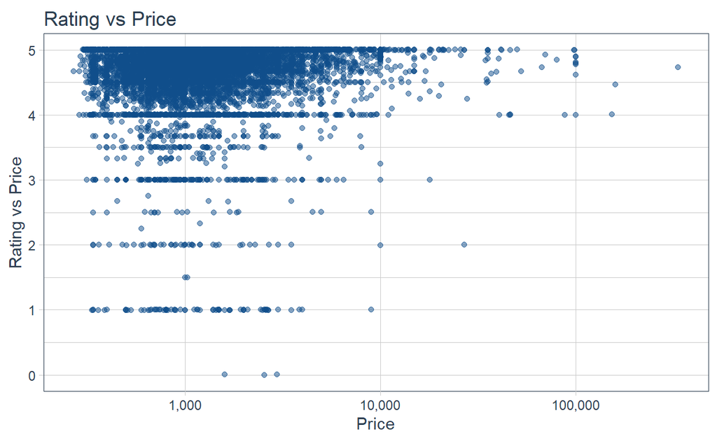

```r
# Colours for correlation plot
c <- c("Aquamarine4", "Sienna3")

# Build correlation plots
q5_1 <- c_plot(q5, q5$review_scores_rating, "Rating vs Price")
q5_2 <- c_plot(q5, q5$review_scores_accuracy, "Accuracy", clr = c[1])
q5_3 <- c_plot(q5, q5$review_scores_cleanliness, "Cleanliness", clr = c[1])
q5_4 <- c_plot(q5, q5$review_scores_checkin, "Check-in", clr = c[1])
q5_5 <- c_plot(q5, q5$review_scores_communication, "Communication", clr = c[2])
q5_6 <- c_plot(q5, q5$review_scores_location, "Location", clr = c[2])
q5_7 <- c_plot(q5, q5$review_scores_value, "Value", clr = c[2])

# Output correlation plots
q5_1
```

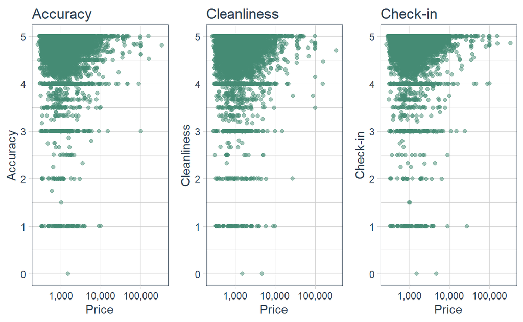

```r
grid.arrange(q5_2, q5_3, q5_4, ncol = 3)
```

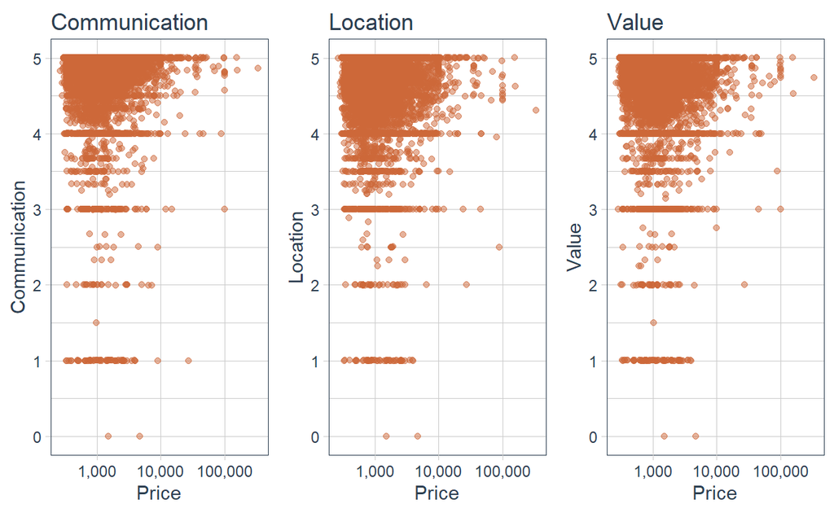

```r
grid.arrange(q5_5, q5_6, q5_7, ncol = 3)
```

1. Using the `cor.test()` function each combination of price and review score
2. Extracting the test’s confidence interval for each correlation test
3. Compiling the results into a table for further examination

```r
# Conduct numerical correlation test
c1 <- cor.test(q5$price, q5$review_scores_rating)
c2 <- cor.test(q5$price, q5$review_scores_accuracy)
c3 <- cor.test(q5$price, q5$review_scores_cleanliness)
c4 <- cor.test(q5$price, q5$review_scores_checkin)
c5 <- cor.test(q5$price, q5$review_scores_communication)
c6 <- cor.test(q5$price, q5$review_scores_location)
c7 <- cor.test(q5$price, q5$review_scores_value)

# Extract correlation test confidence intervals
c1_int <- paste0(round(c1$conf.int[1], 2), ", ", round(c1$conf.int[2], 2))
c2_int <- paste0(round(c2$conf.int[1], 2), ", ", round(c2$conf.int[2], 2))
c3_int <- paste0(round(c3$conf.int[1], 2), ", ", round(c3$conf.int[2], 2))
c4_int <- paste0(round(c4$conf.int[1], 2), ", ", round(c4$conf.int[2], 2))
c5_int <- paste0(round(c5$conf.int[1], 2), ", ", round(c5$conf.int[2], 2))
c6_int <- paste0(round(c6$conf.int[1], 2), ", ", round(c6$conf.int[2], 2))
c7_int <- paste0(round(c7$conf.int[1], 2), ", ", round(c7$conf.int[2], 2))

# Construct data frame of confidence intervals for correlation plots
confidence_intervals <- c(c1_int, c2_int, c3_int, c4_int, c5_int,
                          c6_int, c7_int)

review_category <- c("Rating", "Accuracy", "Cleanliness", "Check–in",
                     "Communication", "Location", "Value")

correlation_df <- data.frame(review_category, confidence_intervals)
correlation_df %>% knitr::kable(align = c("c", "c"))
```

| review_category | confidence_intervals |
| --- | --- |
| Rating | -0.01, 0.03 |
| Accuracy | -0.01, 0.03 |
| Cleanliness | -0.02, 0.02 |
| Check–in | -0.01, 0.02 |
| Communication | -0.02, 0.02 |
| Location | -0.02, 0.02 |
| Value | -0.03, 0.01 |

Looking at our final table, we see that all confidence intervals contain the value 0, which we could interpret to mean that there is no significant correlation between room price and the review score. Users paying for cheap accommodations may be perfectly satisfied with their experience, while paying more does not necessarily guarantee you a higher level of satisfaction.

### Room Listing Geographical Distribution

## Host Queries

### Who are the top 10 host based on revenue?

### Is there any difference in review score between superhost and normal host?

### Is there any difference in response rate between superhost and normal host?

### What is the most commonly verified host information?

### Most Active Months for New Host Sign-Up

*What months of the year have historically seen the most activity in terms of new hosts signing up for the service?*

We begin by extracting and isolating the necessary data using the following steps:

1. Join together the two tables.
2. Select the relevant columns.
3. Convert `host_since_date` to the type `date` using the `as.Date()` function.
4. Separate the `host_since` column into three separate columns for `Year`, `month` and `day` respectively.
5. Discard the unnecessary `day` column.
6. Group by `Year` and `Month` and use the `count()` function to tabulate the results.
7. Construct the necessary columns for the resulting plot and table in the next step
8. Disregard any rows containing `NA` values

```r
q11 <-
    host_info %>%                                                     # 1
    left_join(listing, by = "host_id") %>%
    select(host_id, host_since) %>%                                   # 2
    mutate(host_since_date = as.Date(host_since)) %>%                 # 3
    separate("host_since", c("Year", "Month", "Day"), sep = "-") %>%  # 4
    select(-Day) %>%                                                  # 5
    group_by(Year, Month) %>%                                         # 6
    count(Year, Month) %>%
    ungroup() %>%
    mutate(year_month = paste0(Year, "-", Month, "-", "01"),          # 7
           year_month_2 = paste0(Year, "-", Month),
           joined = n) %>%
    select(year_month, year_month_2, joined) %>%
    mutate(year_month = as.Date(year_month)) %>%
    drop_na()                                                         # 8
```

Next, we use the `ggplot` library’s `geom_line()` function to plot the data as a time series.

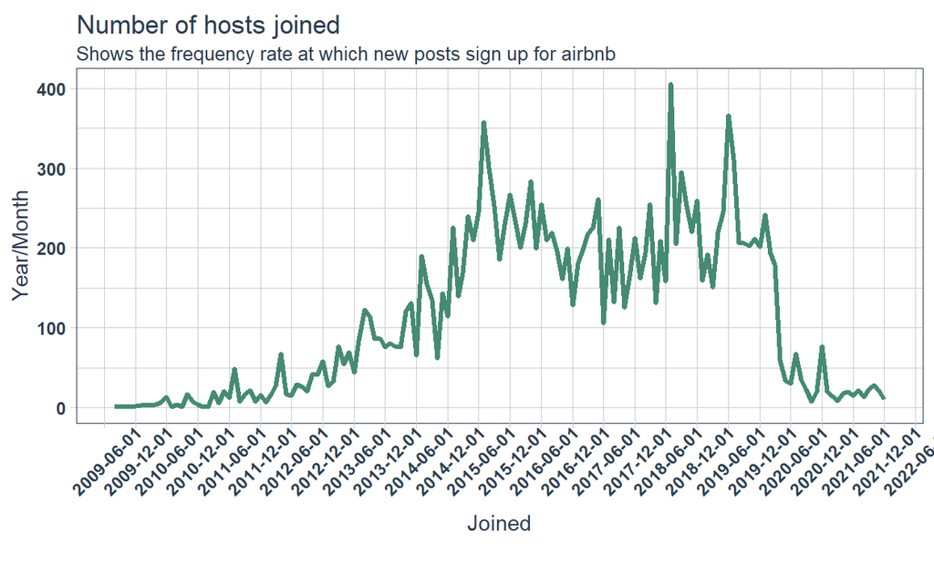

```r
q11 %>%
    ggplot(aes(x = year_month, y = joined)) +
    geom_line(size = 1.2, colour = "Aquamarine4") +
    scale_x_date(breaks = waiver(), date_breaks = "6 months") + theme_tq() +
    theme(axis.text.x = element_text(angle = 45, face = "bold", vjust = 0.65),
          axis.text.y = element_text(face = "bold")) +
    labs(
        title    = "Number of hosts joined",
        subtitle = "Shows the frequency rate at which new posts sign up for airbnb",
        caption  = "",
        x        = "Joined",
        y        = "Year/Month")
```

Since we are dealing with data over a number of years, it is helpful to also compile a list of the top 10 most active months in terms of new hosts

```r
q11 %>%
    select(-year_month) %>%
    mutate(year_month = as.yearmon(year_month_2)) %>%
    select(-year_month_2) %>%
    select(year_month, joined) %>%
    arrange(desc(joined)) %>%
    head(10) %>% knitr::kable(align = c("c", "c"))
```

| year_month | joined |
| --- | --- |
| Jul 2018 | 405 |
| Jun 2019 | 366 |
| Jul 2015 | 358 |
| Jul 2019 | 311 |
| Aug 2015 | 300 |
| Sep 2018 | 295 |
| Apr 2016 | 284 |
| Dec 2015 | 267 |
| May 2017 | 261 |
| Dec 2018 | 259 |